# STAT 253 HW2

Emydius, Hari, Lucy

2022-09-28

# Homework 2

**Due Friday, February 18 at 9:00am CST on [Moodle](https://moodle.macalester.edu/mod/assign/view.php?id=36784)**

**Deliverables:** Please use this template to knit an HTML document. Convert this HTML document to a PDF by opening the HTML document in your web browser. *Print* the document (Ctrl/Cmd-P) and change the destination to “Save as PDF”. Submit this one PDF to Moodle.

Alternatively, you may knit your Rmd directly to PDF if you have LaTeX installed.

## Project Work

### Instructions

**Goal:** Begin an analysis of your dataset to answer your **regression** research question.

**Collaboration:** Form a team (2-3 members) for the project and this part can be done as a team. Only one team member should submit a Project Work section. Make sure you include the full names of all of the members in your write up.

**Data cleaning:** If your dataset requires any cleaning (e.g., merging datasets, creation of new variables), first consult the R Resources page to see if your questions are answered there. If not, post on the #rcode-questions channel in our Slack workspace to ask for help. *Please ask for help early and regularly* to avoid stressful workloads.

### Research question

**Data context:**

“Music Dataset: 1950 to 2019,” collected in a research study in 2020 using Spotify’s Python package and other web APIs, is a dataset consisting of basic information and metadata for 28,372 lyrical tracks released from 1950 to 2019. Each row in the dataset represents a track with its name, artist, release year, genre, lyrics, main topic, and normalized metadata. Here, metadata refers to musical features of a track, such as: danceability, loudness, acousticness, instrumentalness, valence, and energy. Besides, the authors also include normalized data for each of the sixteen topics a track can demonstrate, which ultimately determines its main topic. Examples of such topics are: dating, violence, sadness, romantic, etc.

> It would be interesting to find out about general trends in music across decades. Are there any connections between a song’s release year and its musical features?

### Required Analyses

1. **Initial investigation: ignoring nonlinearity (for now)**

#### Your Work

[output not shown]

```r
# Library statements
library(dplyr);
library(readr);
library(broom);
```

```r
library(ggplot2);
library(tidymodels);
tidymodels_prefer();

# Read in data
music <- read_csv("tcc_ceds_music.csv")
head(music)
```

```
## # A tibble: 6 × 31
##    ...1 artist_name   track…¹ relea…² genre lyrics   len  dating viole…³ world…⁴
##   <dbl> <chr>         <chr>     <dbl> <chr> <chr>  <dbl>   <dbl>   <dbl>   <dbl>
## 1     0 mukesh        mohabb…    1950 pop   hold …    95 5.98e-4 0.0637  5.98e-4
## 2     4 frankie laine i beli…    1950 pop   belie…    51 3.55e-2 0.0968  4.43e-1
## 3     6 johnnie ray   cry        1950 pop   sweet…    24 2.77e-3 0.00277 2.77e-3
## 4    10 pérez prado   patric…    1950 pop   kiss …    54 4.82e-2 0.00155 1.55e-3
## 5    12 giorgos papa… apopse…    1950 pop   till …    48 1.35e-3 0.00135 4.18e-1
## 6    14 perry como    round …    1950 pop   convo…    98 1.05e-3 0.421   1.05e-3
## # … with 21 more variables: `night/time` <dbl>, `shake the audience` <dbl>,
## #   `family/gospel` <dbl>, romantic <dbl>, communication <dbl>, obscene <dbl>,
## #   music <dbl>, `movement/places` <dbl>, `light/visual perceptions` <dbl>,
## #   `family/spiritual` <dbl>, `like/girls` <dbl>, sadness <dbl>,
## #   feelings <dbl>, danceability <dbl>, loudness <dbl>, acousticness <dbl>,
## #   instrumentalness <dbl>, valence <dbl>, energy <dbl>, topic <chr>,
## #   age <dbl>, and abbreviated variable names ¹track_name, ²release_date, …
```

```r
# Data cleaning
music_clean <- select(music, - "...1", -artist_name, -track_name)

head(music_clean)
```

```
## # A tibble: 6 × 28
##   release_d…¹ genre lyrics   len  dating viole…² world…³ night…⁴ shake…⁵ famil…⁶
##         <dbl> <chr> <chr>  <dbl>   <dbl>   <dbl>   <dbl>   <dbl>   <dbl>   <dbl>
## 1        1950 pop   hold …    95 5.98e-4 0.0637  5.98e-4 5.98e-4 5.98e-4 0.0489
## 2        1950 pop   belie…    51 3.55e-2 0.0968  4.43e-1 1.28e-3 1.28e-3 0.0270
## 3        1950 pop   sweet…    24 2.77e-3 0.00277 2.77e-3 2.77e-3 2.77e-3 0.00277
## 4        1950 pop   kiss …    54 4.82e-2 0.00155 1.55e-3 1.55e-3 2.15e-2 0.00155
## 5        1950 pop   till …    48 1.35e-3 0.00135 4.18e-1 1.35e-3 1.35e-3 0.00135
## 6        1950 pop   convo…    98 1.05e-3 0.421   1.05e-3 7.41e-2 1.05e-3 0.00105
## # … with 18 more variables: romantic <dbl>, communication <dbl>, obscene <dbl>,
## #   music <dbl>, `movement/places` <dbl>, `light/visual perceptions` <dbl>,
## #   `family/spiritual` <dbl>, `like/girls` <dbl>, sadness <dbl>,
## #   feelings <dbl>, danceability <dbl>, loudness <dbl>, acousticness <dbl>,
## #   instrumentalness <dbl>, valence <dbl>, energy <dbl>, topic <chr>,
## #   age <dbl>, and abbreviated variable names ¹release_date, ²violence,
## #   ³`world/life`, ⁴`night/time`, ⁵`shake the audience`, ⁶`family/gospel`
```

```r
# Set seed
set.seed(253)

# Creation of CV folds
music_cv <- vfold_cv(data = music_clean, v = 10)
```

```r
# Model specs
lm_spec <-
    linear_reg() %>%
    set_engine(engine = 'lm') %>%
    set_mode('regression')

lm_lasso_spec_tune <-
  linear_reg() %>%
  set_args(mixture = 1, penalty = tune()) %>% ## mixture = 1 indicates Lasso
  set_engine(engine = 'glmnet') %>% #note we are using a different engine
  set_mode('regression')
```

```r
# Recipes & workflows
data_rec <- recipe(release_date ~ danceability + loudness + acousticness + instrumentalness + valence + energy, data = music_clean) %>%
    step_nzv(all_predictors()) %>% # removes variables with the same value
    step_corr()

ols_wf <- workflow() %>%
  add_recipe(data_rec) %>%
  add_model(lm_spec)

lasso_wf_tune <-  workflow() %>%
  add_recipe(data_rec) %>%
  add_model(lm_lasso_spec_tune)
```

```r
# Fit & tune models
## Fit OLS model
ols_mod <- ols_wf %>%
  fit(data = music_clean)

## Fit & tune LASSO model
lasso_mod <- lasso_wf_tune %>%
  fit(data = music_clean)

penalty_grid <- grid_regular(
  penalty(range = c(-3, 1)), #log10 transformed
  levels = 30)

tune_output <- tune_grid( # new function for tuning parameters
  lasso_wf_tune, # workflow
  resamples = music_cv, # cv folds
  metrics = metric_set(rmse, rsq, mae),
  grid = penalty_grid # penalty grid defined above
)
```

[output not shown]

[output not shown]

[output not shown]

[output not shown]

[output not shown]

[output not shown]

[output not shown]

[output not shown]

[output not shown]

[output not shown]

```
c. Estimate the test performance of the models using CV. Report and interpret (with units) the CV metric estimates along with a measure of uncertainty in the estimate (`std_error` is readily available when you used `collect_metrics(summarize=TRUE)`).
  - Compare estimated test performance across the models. Which models(s) might you prefer?
```

```r
# Calculate/collect CV metrics
## OLS model's CV metrics
ols_cv <- fit_resamples(ols_wf,
  resamples = music_cv,
  metrics = metric_set(rmse, rsq, mae)
)

ols_cv %>% collect_metrics(summarize=TRUE)
```

```
## # A tibble: 3 × 6
##   .metric .estimator   mean     n std_err .config
##   <chr>   <chr>       <dbl> <int>   <dbl> <chr>
## 1 mae     standard   12.1      10 0.0437  Preprocessor1_Model1
## 2 rmse    standard   14.7      10 0.0474  Preprocessor1_Model1
## 3 rsq     standard    0.370    10 0.00357 Preprocessor1_Model1
```

```r
## LASSO models CV metrics
tune_output %>% collect_metrics(summarize=TRUE)
```

```
## # A tibble: 90 × 7
##    penalty .metric .estimator   mean     n std_err .config
##      <dbl> <chr>   <chr>       <dbl> <int>   <dbl> <chr>
##  1 0.001   mae     standard   12.1      10 0.0437  Preprocessor1_Model01
##  2 0.001   rmse    standard   14.7      10 0.0474  Preprocessor1_Model01
##  3 0.001   rsq     standard    0.370    10 0.00358 Preprocessor1_Model01
##  4 0.00137 mae     standard   12.1      10 0.0437  Preprocessor1_Model02
##  5 0.00137 rmse    standard   14.7      10 0.0474  Preprocessor1_Model02
##  6 0.00137 rsq     standard    0.370    10 0.00358 Preprocessor1_Model02
##  7 0.00189 mae     standard   12.1      10 0.0437  Preprocessor1_Model03
##  8 0.00189 rmse    standard   14.7      10 0.0474  Preprocessor1_Model03
##  9 0.00189 rsq     standard    0.370    10 0.00358 Preprocessor1_Model03
## 10 0.00259 mae     standard   12.1      10 0.0437  Preprocessor1_Model04
## # … with 80 more rows
```

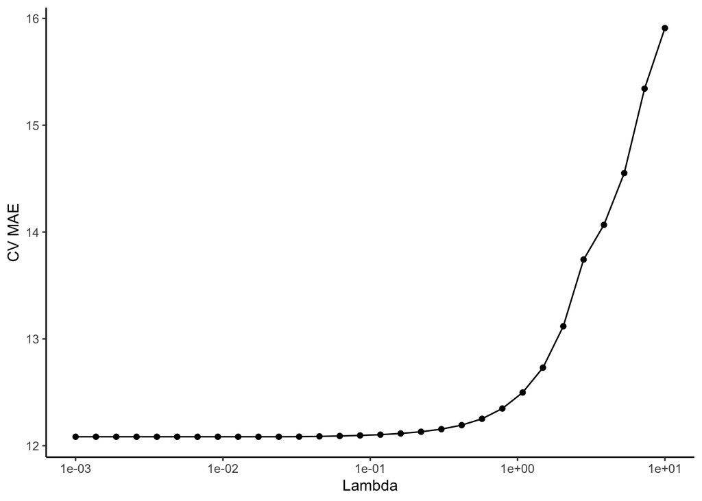

```r
metrics_output <- collect_metrics(tune_output) %>%
  filter(.metric == 'mae')

metrics_output %>% ggplot(aes(x = penalty, y = mean)) +
  geom_point() +
  geom_line() +
  labs(x = 'Lambda', y = 'CV MAE') +
  scale_x_log10() +
  theme_classic()
```

```r
## Best LASSO model's CV MAE
best_penalty <- select_best(tune_output, metric = 'mae') # choose penalty value based on lowest cv mae
best_penalty
```

```
## # A tibble: 1 × 2
##   penalty .config
##     <dbl> <chr>
## 1   0.001 Preprocessor1_Model01
```

```r
best_se_penalty <- select_by_one_std_err(tune_output, metric = 'mae', desc(penalty)) # choose largest penalty value within 1 se of the lowest cv mae
best_se_penalty
```

```
## # A tibble: 1 × 9
##   penalty .metric .estimator  mean     n std_err .config            .best .bound
##     <dbl> <chr>   <chr>      <dbl> <int>   <dbl> <chr>              <dbl>  <dbl>
## 1   0.161 mae     standard    12.1    10  0.0442 Preprocessor1_Mod…  12.1   12.1
```

MAE results from cross-validation of the OLS model and the best LASSO models (penalty = 0.001, and penalty = 0.1610262) are respectively 12.0784177 ± 0.04368178 years, 12.0838520 ± 0.043719815 years, and 12.11439 ± 0.04423626 years. In the best case scenario (subtracting the standard error from the mean MAE), predictions of these models would be off by 12.03473592 years, 12.040132185 years, and 12.07015374 years respectively. This means that on average, our predictions are about 12 years sooner or later than the real release year, with the OLS model having a slightly closer guess than the best LASSO models.

Comparison of the MAE of the models show that the OLS model (`ols_mod`) is the best, because it has the lowest average MAE after 10-fold cross-validation (so there is few to none overfitting).

```
d. Use residual plots to evaluate whether some quantitative predictors might be better modeled with nonlinear relationships.
```

```r
ols_mod_output <- ols_mod %>%
    predict(new_data = music_clean) %>%
    bind_cols(music_clean) %>%
    mutate(resid = release_date - .pred) #observed - predicted

head(ols_mod_output)
```

```
## # A tibble: 6 × 30
##   .pred release_date genre lyrics    len  dating viole…¹ world…² night…³ shake…⁴
##   <dbl>        <dbl> <chr> <chr>   <dbl>   <dbl>   <dbl>   <dbl>   <dbl>   <dbl>
## 1 1971.         1950 pop   hold t…    95 5.98e-4 0.0637  5.98e-4 5.98e-4 5.98e-4
## 2 1978.         1950 pop   believ…    51 3.55e-2 0.0968  4.43e-1 1.28e-3 1.28e-3
## 3 1979.         1950 pop   sweeth…    24 2.77e-3 0.00277 2.77e-3 2.77e-3 2.77e-3
## 4 1998.         1950 pop   kiss l…    54 4.82e-2 0.00155 1.55e-3 1.55e-3 2.15e-2
## 5 1970.         1950 pop   till d…    48 1.35e-3 0.00135 4.18e-1 1.35e-3 1.35e-3
## 6 1982.         1950 pop   convoy…    98 1.05e-3 0.421   1.05e-3 7.41e-2 1.05e-3
## # … with 20 more variables: `family/gospel` <dbl>, romantic <dbl>,
## #   communication <dbl>, obscene <dbl>, music <dbl>, `movement/places` <dbl>,
## #   `light/visual perceptions` <dbl>, `family/spiritual` <dbl>,
## #   `like/girls` <dbl>, sadness <dbl>, feelings <dbl>, danceability <dbl>,
## #   loudness <dbl>, acousticness <dbl>, instrumentalness <dbl>, valence <dbl>,
## #   energy <dbl>, topic <chr>, age <dbl>, resid <dbl>, and abbreviated variable
## #   names ¹violence, ²`world/life`, ³`night/time`, ⁴`shake the audience`
```

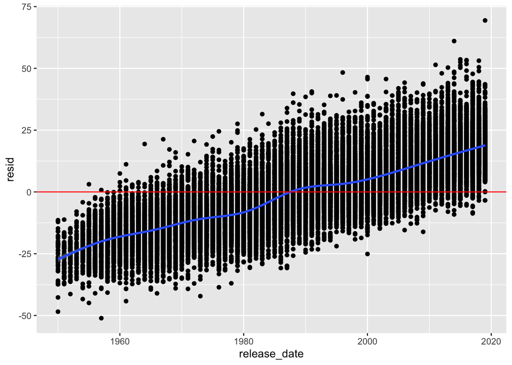

```r
# Visualize residuals
## Residuals vs. release_date (outcome variable)
ggplot(ols_mod_output, aes(x = release_date, y = resid)) +
    geom_point() +
    geom_smooth() +
    geom_hline(yintercept = 0, color = "red")
```

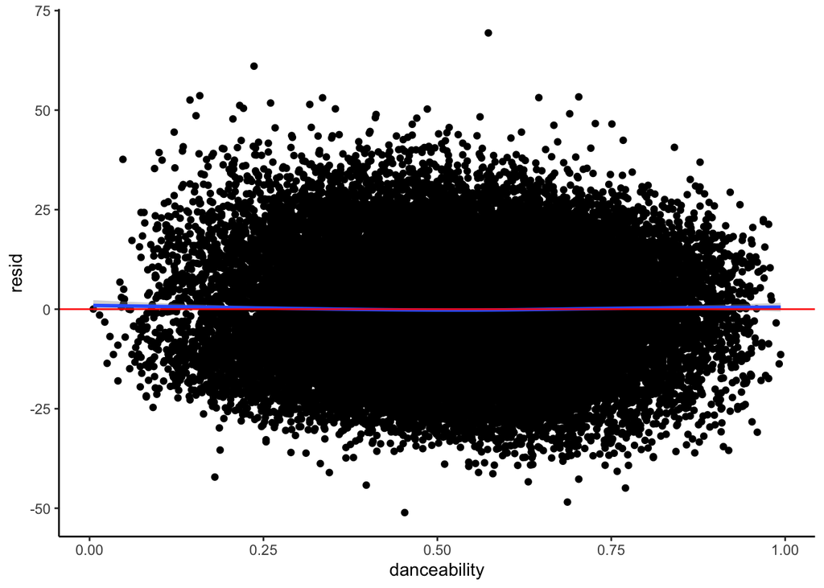

```r
## Residuals vs. danceability
ggplot(ols_mod_output, aes(x = danceability, y = resid)) +
    geom_point() +
    geom_smooth() +
    geom_hline(yintercept = 0, color = "red") +
    theme_classic()
```

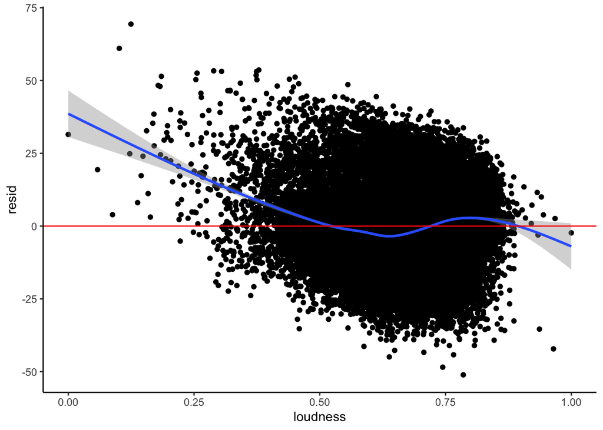

```r
## Residuals vs. loudness
ggplot(ols_mod_output, aes(x = loudness, y = resid)) +
    geom_point() +
    geom_smooth() +
    geom_hline(yintercept = 0, color = "red") +
    theme_classic()
```

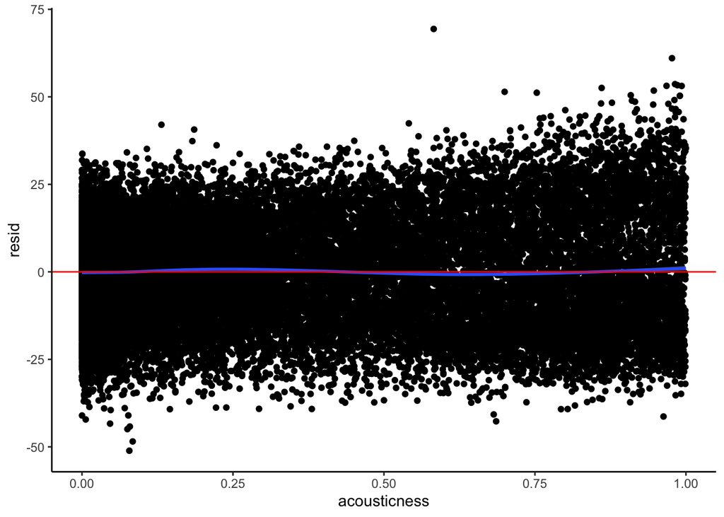

```r
## Residuals vs. acousticness
ggplot(ols_mod_output, aes(x = acousticness, y = resid)) +
    geom_point() +
    geom_smooth() +
    geom_hline(yintercept = 0, color = "red") +
    theme_classic()
```

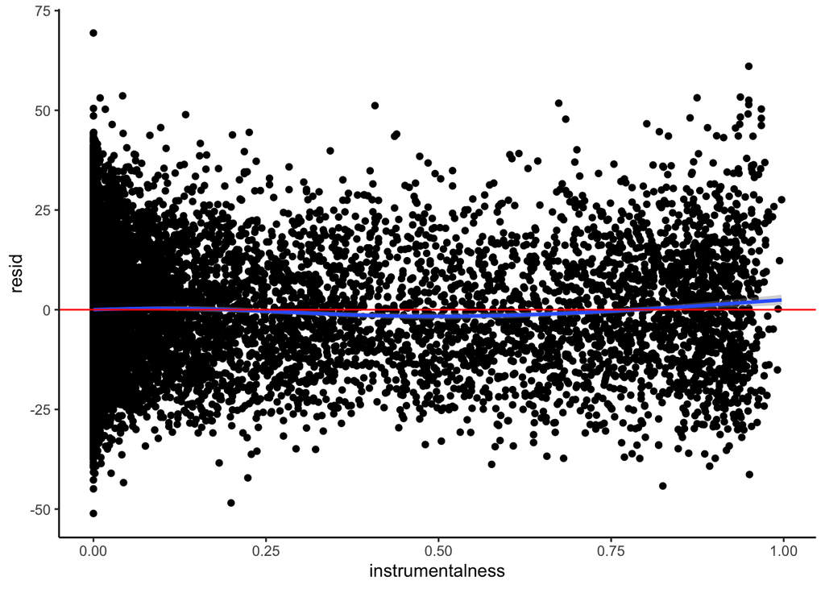

```r
## Residuals vs. instrumentalness
ggplot(ols_mod_output, aes(x = instrumentalness, y = resid)) +
    geom_point() +
    geom_smooth() +
    geom_hline(yintercept = 0, color = "red") +
    theme_classic()
```

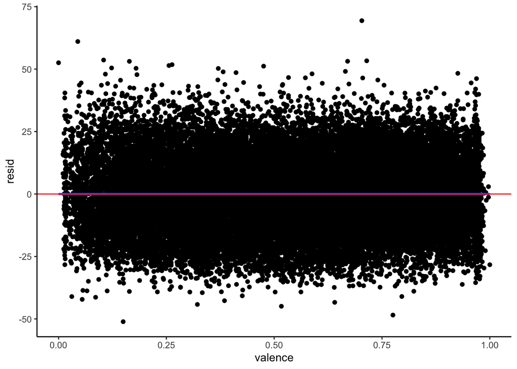

```r
## Residuals vs. valence
ggplot(ols_mod_output, aes(x = valence, y = resid)) +
    geom_point() +
    geom_smooth() +
    geom_hline(yintercept = 0, color = "red") +
    theme_classic()
```

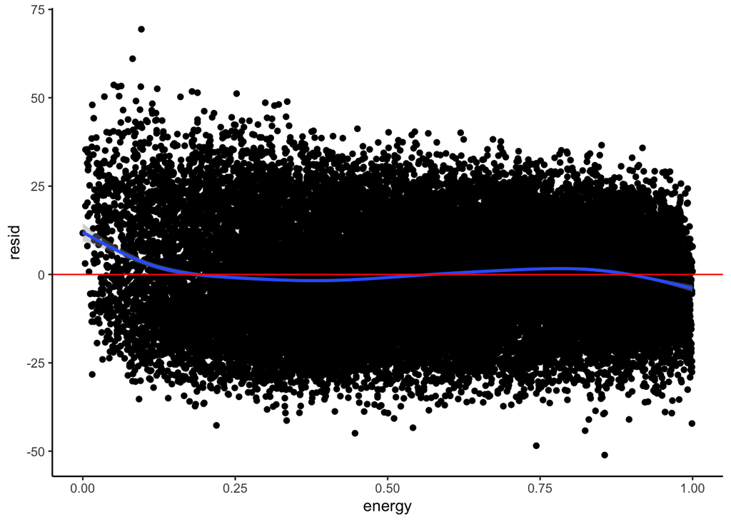

```r
## Residuals vs. energy
ggplot(ols_mod_output, aes(x = energy, y = resid)) +
    geom_point() +
    geom_smooth() +
    geom_hline(yintercept = 0, color = "red") +
    theme_classic()
```

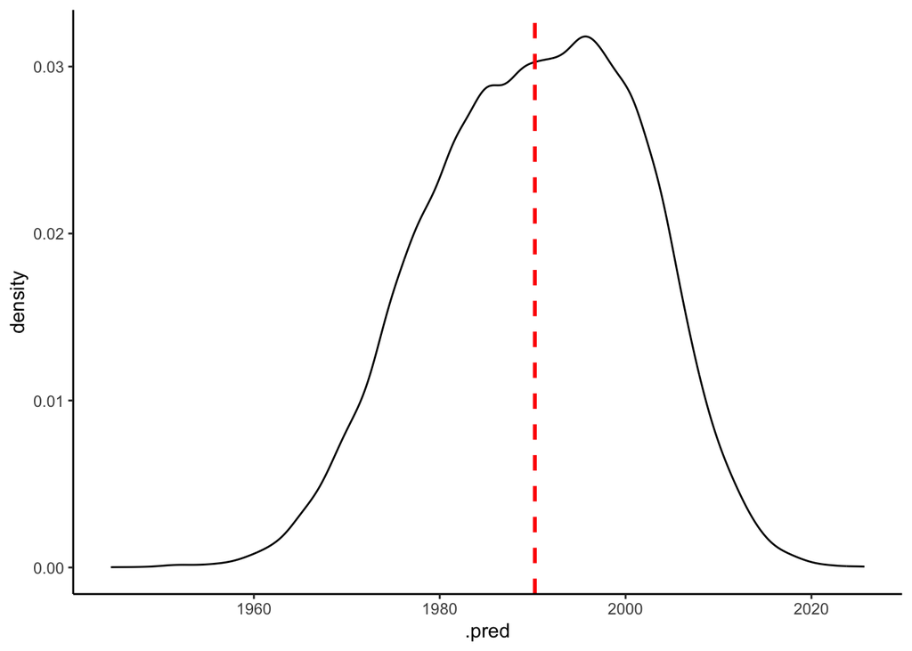

```r
# visualize predicted vs. observed data
ggplot(ols_mod_output, aes(x = .pred)) +
    geom_density() +
    geom_vline(aes(xintercept=mean(.pred)),
            color="red", linetype="dashed", size=1) +
    theme_classic()
```

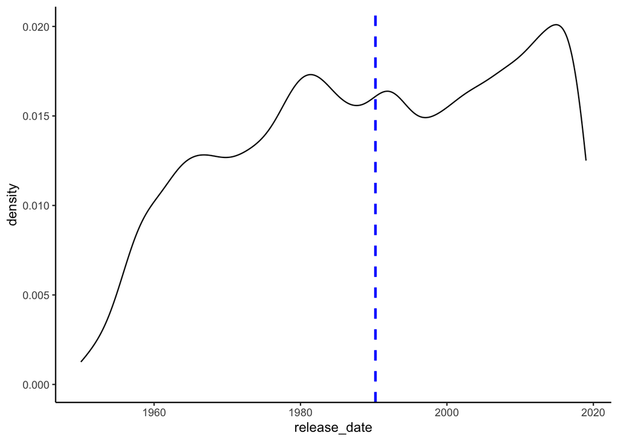

```r
ggplot(ols_mod_output, aes(x = release_date)) +
    geom_density() +
    geom_vline(aes(xintercept=mean(.pred)),
            color="blue", linetype="dashed", size=1) +
    theme_classic()
```

It seems that we do not have a very strong prediction power in our model, because with all the predictors included, our model still tends to average out the predictions (shown by a normal distribution in the density plot). This is also quantified by the R-squared of `ols_mod`, which is only 37.01227%. Although it is rather disappointing to have an R-squared this low for the best model, in the context of this dataset and our research question, it makes sense, because musical trends are usually not clear-cut, and there can be a lot of “mix and match” where typical features of one “era” are brought into a later “era”. Therefore, variations in songs’ release years should not be accounted too much by musical features.

However, a look into the coefficients of these musical feature variables still tells us many interesting insights.

```
e. Which variables do you think are the most important predictors of your quantitative outcome? Justify your answer. Do the methods you've applied reach consensus on which variables are most important? What insights are expected? Surprising?
- Note that if some (but not all) of the indicator terms for a categorical predictor are selected in the final models, the whole predictor should be treated as selected.
```

```r
# Show coefficient estimates
## OLS model
ols_mod %>% tidy()
```

```
## # A tibble: 7 × 5
##   term             estimate std.error statistic   p.value
##   <chr>               <dbl>     <dbl>     <dbl>     <dbl>
## 1 (Intercept)      1950.        0.792  2462.    0
## 2 danceability       31.8       0.605    52.5   0
## 3 loudness           62.1       1.33     46.7   0
## 4 acousticness      -14.7       0.395   -37.2   1.19e-295
## 5 instrumentalness    5.26      0.425    12.4   5.21e- 35
## 6 valence           -24.7       0.435   -56.9   0
## 7 energy              0.216     0.749     0.288 7.73e-  1
```

```r
ols_mod_output %>% summarise(mean = mean(.pred), sd = sd(.pred), max = max(.pred), min = min(.pred))
```

```
## # A tibble: 1 × 4
##    mean    sd   max   min
##   <dbl> <dbl> <dbl> <dbl>
## 1 1990.  11.2 2026. 1945.
```

```r
## LASSO models
final_wf <- finalize_workflow(lasso_wf_tune, best_penalty) # incorporates penalty value to workflow
final_fit <- fit(final_wf, data = music_clean)

final_fit %>% tidy()
```

```
## # A tibble: 7 × 3
##   term              estimate penalty
##   <chr>                <dbl>   <dbl>
## 1 (Intercept)      1950.       0.001
## 2 danceability       31.4      0.001
## 3 loudness           62.1      0.001
## 4 acousticness      -14.7      0.001
## 5 instrumentalness    5.12     0.001
## 6 valence           -24.4      0.001
## 7 energy              0.0131   0.001
```

```r
final_wf_se <- finalize_workflow(lasso_wf_tune, best_se_penalty) # incorporates penalty value to workflow
final_fit_se <- fit(final_wf_se, data = music_clean)
tidy(final_fit_se)
```

```
## # A tibble: 7 × 3
##   term             estimate penalty
##   <chr>               <dbl>   <dbl>
## 1 (Intercept)       1951.     0.161
## 2 danceability        29.8    0.161
## 3 loudness            60.8    0.161
## 4 acousticness       -14.5    0.161
## 5 instrumentalness     4.41   0.161
## 6 valence            -23.3    0.161
## 7 energy               0      0.161
```

Based on the absolute values of the coefficient estimates, the most important predictors in our model are in order: loudness, danceability, valence, and acousticness. This order of importance is also true for the best LASSO models.

From the coefficients, we can infer that in general, later songs are more danceable, a lot louder, less acoustic, slightly more instrumental, less positive (valence), and have just a little more energy. The trends of higher danceability and less acousticness are expected, but it is quite surprising that loudness plays such an important role (twice as much as danceability - the second most important predictor) in our model. This could be due to the advancement in audio recording technologies over time, given that [1975 marks the start of the Digital Era](https://en.wikipedia.org/wiki/History_of_sound_recording).

Another interesting insight is in the considerable, negative coefficient of valence, which is the musical positiveness (happy, cheerful, euphoric vs. sad, depressed, angry) conveyed by a track. Up to nearly 25 years is the estimated difference in release year between the happiest song and the saddest song possible. One plausible explanation for this trend is the rise of musical genres like Emo, Indie, Gothic Metal, Doom Metal, etc. However, this needs a closer look into the `genre` column of our dataset, since the dataset may not include songs of these musical genres or may not represent the total population with regards to these movements.

2. **Summarize investigations**
   - Decide on an overall best model based on your investigations so far. To do this, make clear your analysis goals. Predictive accuracy? Interpretability? A combination of both?

OLS is the overall best model. Among our predictors, `energy` is the only one that seems irrelevant, whose coefficient is shrunk to 0 in LASSO model 17 (penalty = 0.1610262). However, because `energy`’s coefficient in the OLS model is only 0.2156978 years (which means it does not affect the outcome much), and because OLS overall generates slightly more accurate predictions than LASSO, we chose OLS to be our final model. This is for the sake of both predictive accuracy and interpretability of the model output (while LASSO here only excludes one less relevant predictor, interpretation of OLS models are generally much simpler).

3. **Societal impact**
   - Are there any harms that may come from your analyses and/or how the data were collected?
   - What cautions do you want to keep in mind when communicating your work?

One harm we should consider is the possibility of the overgeneralization of music trends. One of our planned research questions is to see if we can predict the year a song was released based on its attributes like valence, danceability, etc. However, this essentially ties a specific year to a specific kind of genre and we do not want to perpetuate any stereotypes such as modern music being more about violence or being negative, etc. We just want to highlight some overall trends and not ignore the fact that at any year, music of many different genres is still made. Another caution we should keep in mind is that this dataset is limited to the Spotify library since these values are from the Spotify API. Our songs are also limited to English songs, so we only see trends for a specific language. In addition, the values we are getting from the Spotify API are from AI, so the values have the possibility to be subjective. A caution from our analysis is that with the variables we used we see a trend in the data but the predictive power of our current model is low due to the R-squared value.